# Data 624 - Project 1

#### ATM 1

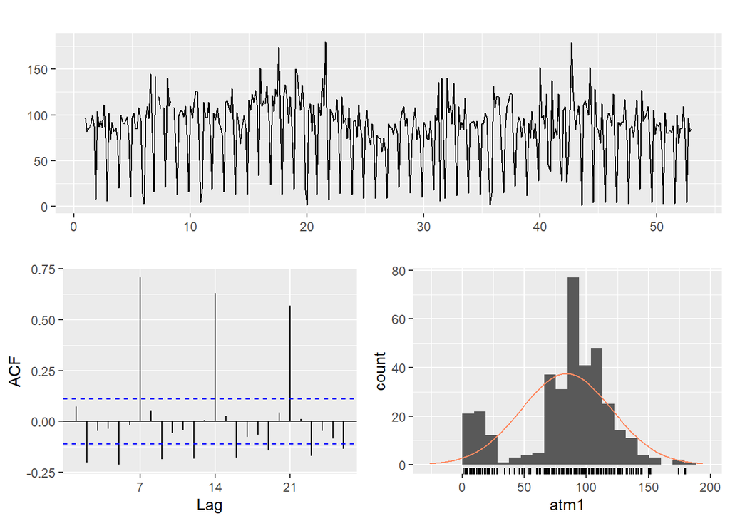

```r
atm1 <- atm_ts[,1]
atm1<-ts(atm1, frequency = 7)
ggtsdisplay(atm1, points = FALSE, plot.type = "histogram")
```

- Seasonality in the data
- Huge lag spikes, will need to understand better after the Box-Cox transform

#### ATM 2

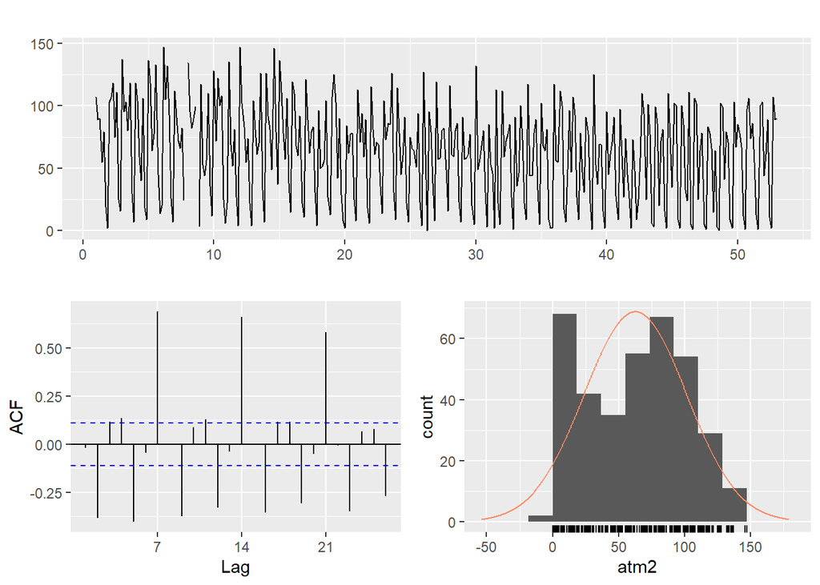

```r
atm2 <- atm_ts[,2]
atm2<-ts(atm2, frequency = 7)
ggtsdisplay(atm2, points = FALSE, plot.type = "histogram")
```

- Seasonality in the data
- Huge lag spikes, will need to understand better after the Box-Cox transform

#### ATM 3

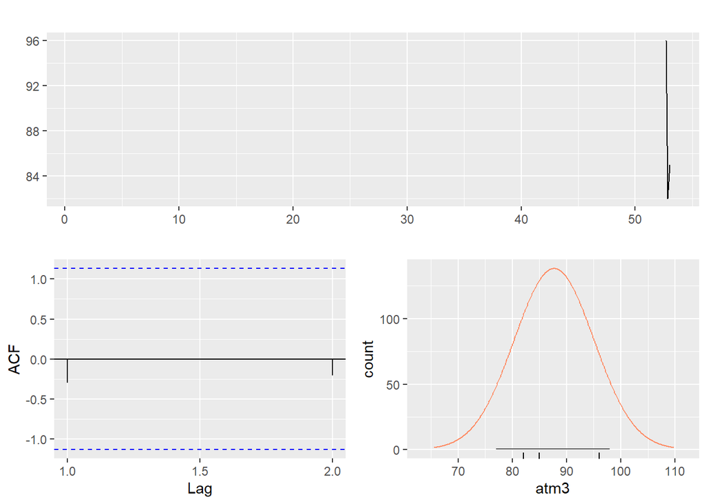

```r
atm3 <- atm_ts[,3]
atm3[which(atm3 == 0)]<-NA
atm3<-ts(atm3, frequency = 7)
ggtsdisplay(atm3, points = FALSE, plot.type = "histogram")
```

- Only 3 observations in the data
  - Not sure if there is enough data to accurately predict the needed amount of cash.
- May need to use median for prediction

#### ATM 4

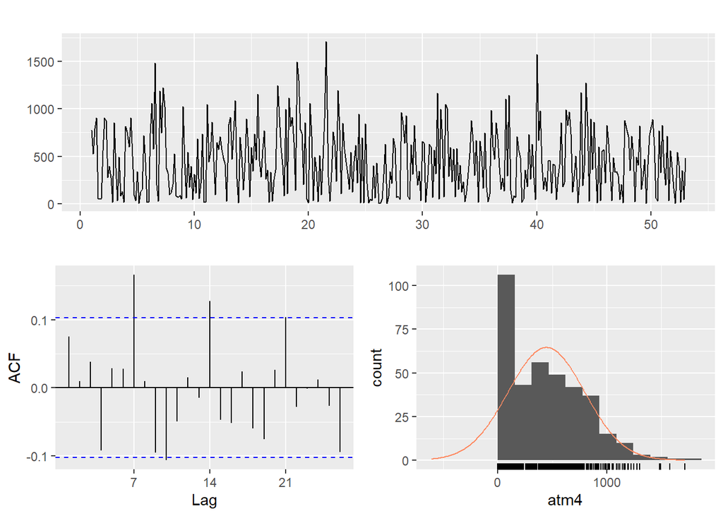

```r
atm4 <- atm_ts[,4]
atm4[which.max(atm4)]<-median(atm4, na.rm = TRUE)
atm4<-ts(atm4, frequency = 7)
ggtsdisplay(atm4, points = FALSE, plot.type = "histogram")
```

- With the outlier brought back down using median the data is in a good stage to move forward
- Not sure if we are seeing seasonality

### Creating Forecast models

All Models will start with a Box-Cox transform as it is the simplest transform method. Each will be evaluated to see if the transform is beneficial, gets removed, or if other steps are required.

#### ATM1

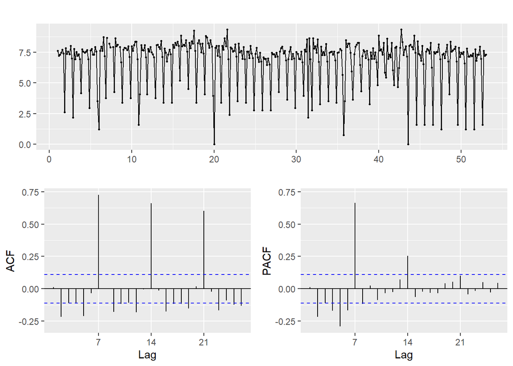

```r
atm1_lambda <- BoxCox.lambda(atm1)
ggtsdisplay(atm1  %>% BoxCox(atm1_lambda))
```

```r
ur.kpss(atm1  %>% BoxCox(atm1_lambda)) %>% summary
```

```
##
## #######################
## # KPSS Unit Root Test #
## #######################
##
## Test is of type: mu with 5 lags.
##
## Value of test-statistic is: 0.3929
##
## Critical value for a significance level of:
##                 10pct  5pct 2.5pct  1pct
## critical values 0.347 0.463  0.574 0.739
```

- We still see regular lag spikes at 7, 14, and 21

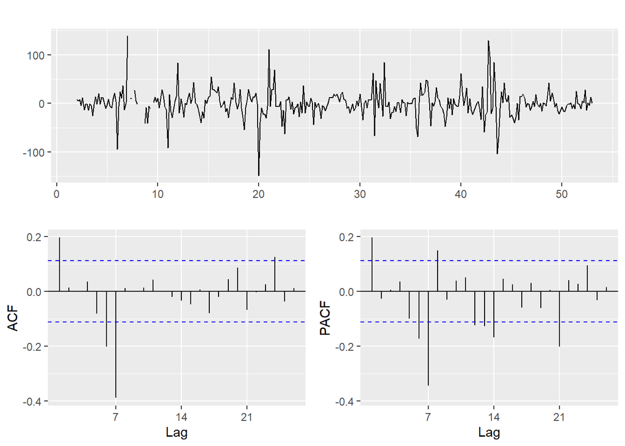

```r
ggtsdisplay(diff(atm1, 7), points = FALSE)
```

```r
ur.kpss(diff(atm1, 7)) %>% summary
```

```
##
## #######################
## # KPSS Unit Root Test #
## #######################
##
## Test is of type: mu with 5 lags.
##
## Value of test-statistic is: 0.0259
##
## Critical value for a significance level of:
##                 10pct  5pct 2.5pct  1pct
## critical values 0.347 0.463  0.574 0.739
```

- Setting the differential at 7 to account for the regular spikes seems to do the trick and reduce the test statistic

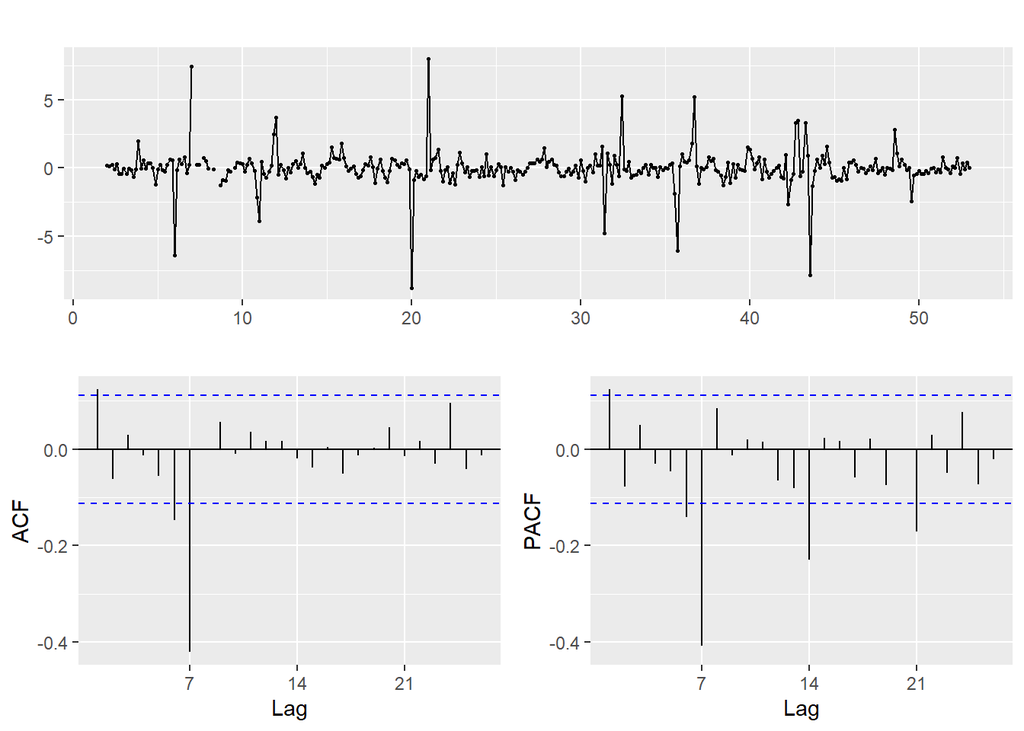

```r
ggtsdisplay(atm1  %>% BoxCox(atm1_lambda)%>% diff(7))
```

```r
ur.kpss(atm1  %>% BoxCox(atm1_lambda) %>% diff(7)) %>% summary
```

```
##
## #######################
## # KPSS Unit Root Test #
## #######################
##
## Test is of type: mu with 5 lags.
##
## Value of test-statistic is: 0.016
##
## Critical value for a significance level of:
##                 10pct  5pct 2.5pct  1pct
## critical values 0.347 0.463  0.574 0.739
```

- Success with a Box-Cox and Diff of 7
- This leads to an Arima model of 2,0,2 with seasonally of 0,1,1

```r
atm_model1 <- Arima(atm1, order=c(2,0,2), seasonal = c(0,1,1), lambda = atm1_lambda)
summary(atm_model1)
```

```
## Series: atm1
## ARIMA(2,0,2)(0,1,1)[7]
## Box Cox transformation: lambda= 0.2081476
##
## Coefficients:
##           ar1      ar2     ma1     ma2     sma1
##       -0.5362  -0.8226  0.6000  0.7602  -0.6945
## s.e.   0.1342   0.1455  0.1418  0.1770   0.0433
##
## sigma^2 estimated as 1.244:  log likelihood=-542.33
## AIC=1096.67   AICc=1096.9   BIC=1119.95
##
## Training set error measures:
##                    ME     RMSE      MAE       MPE     MAPE      MASE
## Training set 2.522885 24.94303 16.01159 -85.35837 104.6165 0.9058306
##                    ACF1
## Training set 0.06631228
```

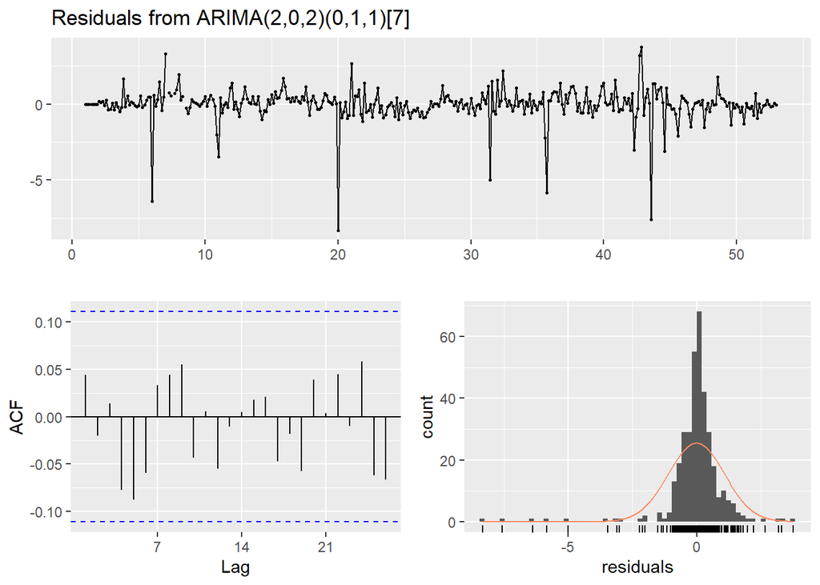

```
##
##  Ljung-Box test
##
## data:  Residuals from ARIMA(2,0,2)(0,1,1)[7]
## Q* = 7.3162, df = 9, p-value = 0.6042
##
## Model df: 5.   Total lags used: 14
```

```r
checkresiduals(atm_model1)
```

```r
atm1_check <- auto.arima(atm1, approximation = FALSE, lambda = atm1_lambda)
summary(atm1_check)
```

```
## Series: atm1
## ARIMA(0,0,2)(0,1,1)[7]
## Box Cox transformation: lambda= 0.2081476
##
## Coefficients:
##          ma1      ma2     sma1
##       0.0989  -0.1107  -0.6482
## s.e.  0.0532   0.0527   0.0425
##
## sigma^2 estimated as 1.247:  log likelihood=-543.68
## AIC=1095.37   AICc=1095.48   BIC=1110.89
##
## Training set error measures:
##                    ME     RMSE      MAE       MPE     MAPE      MASE
## Training set 2.493867 25.19797 16.12913 -88.12706 107.3975 0.9124807
##                    ACF1
## Training set 0.01895515
```

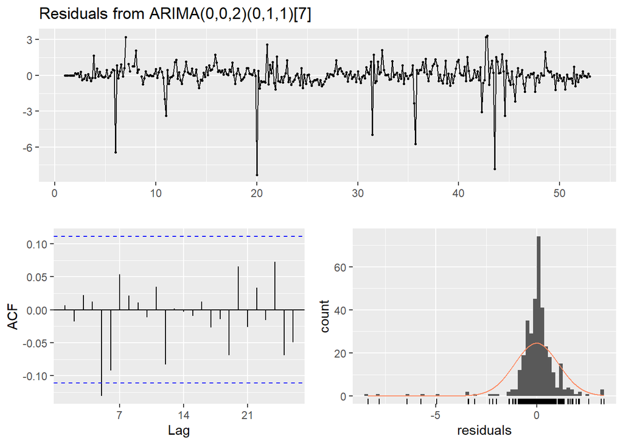

```
##
##  Ljung-Box test
##
## data:  Residuals from ARIMA(0,0,2)(0,1,1)[7]
## Q* = 8.5811, df = 11, p-value = 0.6605
##
## Model df: 3.   Total lags used: 14
```

```r
checkresiduals(atm1_check)
```

- The Auto Arima model came up with a (0,0,2)(0,1,1)[7]
- I chose (2,0,2)(0,1,1)[7]
- According to the residuals, both models represent the data well as the residuals are not distinguishable from white noise.
- The AICc is lower for the auto model and the P-Value is lower for the manual
- I will keep the manual model

#### ATM2

No Transforms

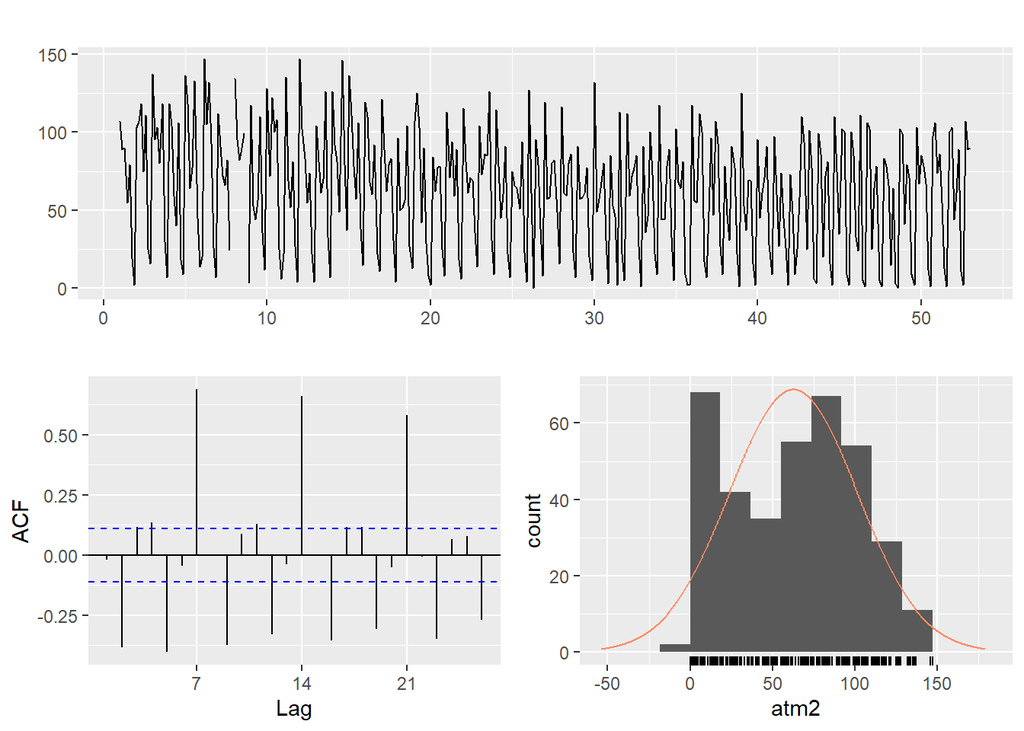

```r
ggtsdisplay(atm2, points = FALSE, plot.type = "histogram")
```

```r
ur.kpss(atm2) %>% summary
```

```
##
## #######################
## # KPSS Unit Root Test #
## #######################
##
## Test is of type: mu with 5 lags.
##
## Value of test-statistic is: 2.1698
##
## Critical value for a significance level of:
##                 10pct  5pct 2.5pct  1pct
## critical values 0.347 0.463  0.574 0.739
```

Box-Cox Transform

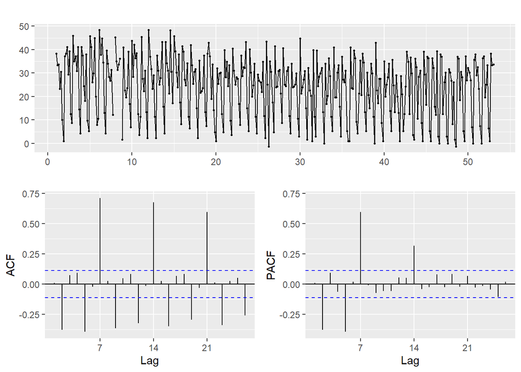

```r
atm2_lambda <- BoxCox.lambda(atm2)

ggtsdisplay(atm2  %>% BoxCox(atm2_lambda))
```

```r
ur.kpss(atm2 %>% BoxCox(atm2_lambda)) %>% summary
```

```
##
## #######################
## # KPSS Unit Root Test #
## #######################
##
## Test is of type: mu with 5 lags.
##
## Value of test-statistic is: 2.1556
##
## Critical value for a significance level of:
##                 10pct  5pct 2.5pct  1pct
## critical values 0.347 0.463  0.574 0.739
```

- The Box-Cox transform did not change the data much
  - Perhaps I should start with a general diff()

```r
ndiffs(atm2)
```

```
## [1] 1
```

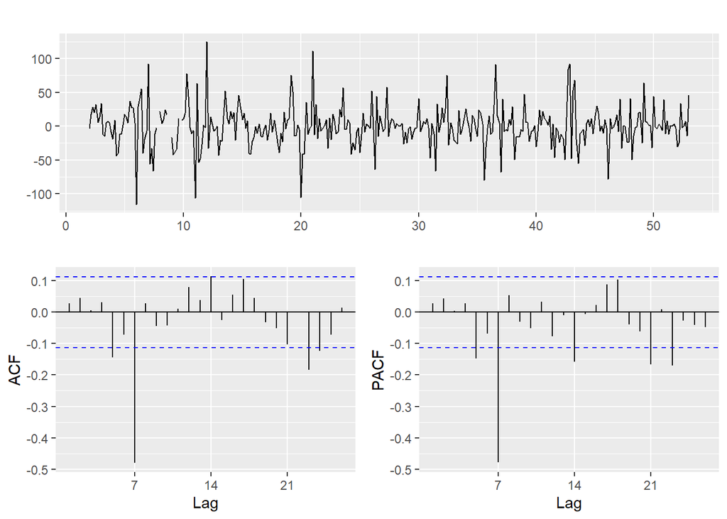

```r
ggtsdisplay(diff(atm2, 7), points = FALSE)
```

```r
ur.kpss(diff(atm2, 7)) %>% summary
```

```
##
## #######################
## # KPSS Unit Root Test #
## #######################
##
## Test is of type: mu with 5 lags.
##
## Value of test-statistic is: 0.0168
##
## Critical value for a significance level of:
##                 10pct  5pct 2.5pct  1pct
## critical values 0.347 0.463  0.574 0.739
```

- The Lag Spike at 7 and the differential check returning 1 I’ll start my model with a (2,1,2)(0,1,1)

```r
atm_model2<- Arima(atm2, order=c(2,1,2), seasonal = c(0,1,1), lambda = atm2_lambda)
summary(atm_model2)
```

```
## Series: atm2
## ARIMA(2,1,2)(0,1,1)[7]
## Box Cox transformation: lambda= 0.7164431
##
## Coefficients:
##           ar1      ar2      ma1      ma2     sma1
##       -0.0359  -0.1078  -0.9285  -0.0715  -0.6228
## s.e.   0.2651   0.0569   0.2633   0.2631   0.0450
##
## sigma^2 estimated as 65.42:  log likelihood=-1249.21
## AIC=2510.42   AICc=2510.66   BIC=2533.69
##
## Training set error measures:
##                     ME    RMSE      MAE  MPE MAPE      MASE        ACF1
## Training set 0.6080112 24.9517 17.33436 -Inf  Inf 0.8461616 -0.01891811
```

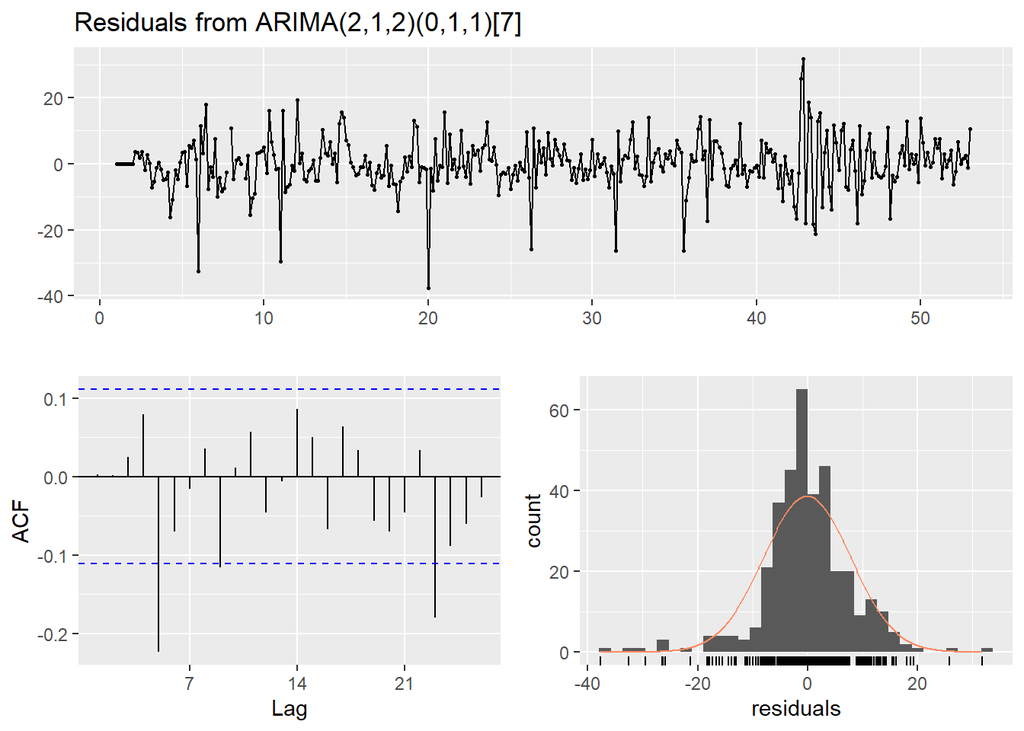

```
##
##  Ljung-Box test
##
## data:  Residuals from ARIMA(2,1,2)(0,1,1)[7]
## Q* = 26.39, df = 9, p-value = 0.001763
##
## Model df: 5.   Total lags used: 14
```

```r
checkresiduals(atm_model2)
```

```r
atm2_check <- auto.arima(atm2, approximation = FALSE, lambda = atm2_lambda)
summary(atm2_check)
```

```
## Series: atm2
## ARIMA(2,0,2)(0,1,1)[7]
## Box Cox transformation: lambda= 0.7164431
##
## Coefficients:
##           ar1      ar2     ma1     ma2     sma1
##       -0.4188  -0.9019  0.4587  0.7886  -0.7187
## s.e.   0.0587   0.0471  0.0884  0.0619   0.0414
##
## sigma^2 estimated as 62.19:  log likelihood=-1240.08
## AIC=2492.16   AICc=2492.4   BIC=2515.45
##
## Training set error measures:
##                     ME     RMSE      MAE  MPE MAPE      MASE        ACF1
## Training set 0.2631418 24.22403 16.90092 -Inf  Inf 0.8250038 -0.01464052
```

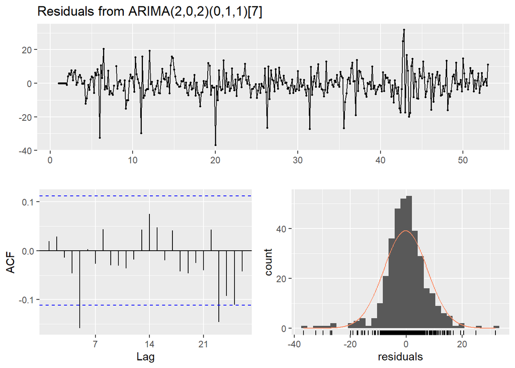

```
##
##  Ljung-Box test
##
## data:  Residuals from ARIMA(2,0,2)(0,1,1)[7]
## Q* = 9.8051, df = 9, p-value = 0.3665
##
## Model df: 5.   Total lags used: 14
```

```r
checkresiduals(atm2_check)
```

#### ATM3

I had a hard time figuring out what to do with this model. There is only 3 observations in the dataset. After doing research, I chose a random walk model vs an average model using the non-zero observations.

```r
#atm3_lambda <- BoxCox.lambda(atm3) # lambda for ATM3 will not be required

atm_model3 <- rwf(atm3, h=31)
```

#### ATM4

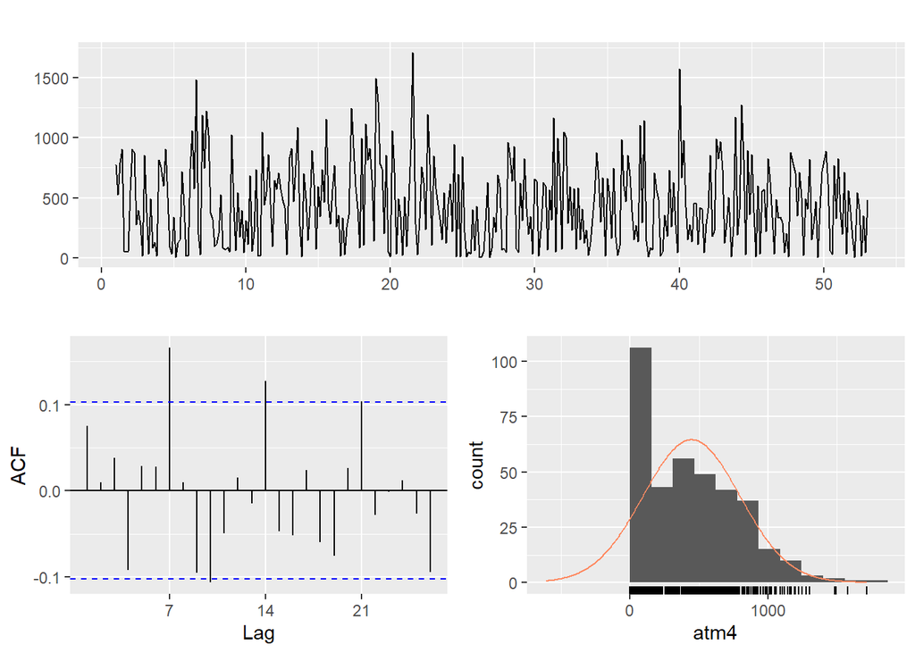

```r
atm4_lambda <- BoxCox.lambda(atm4)

ggtsdisplay(atm4, points = FALSE, plot.type = "histogram")
```

```r
ndiffs(atm4)
```

```
## [1] 0
```

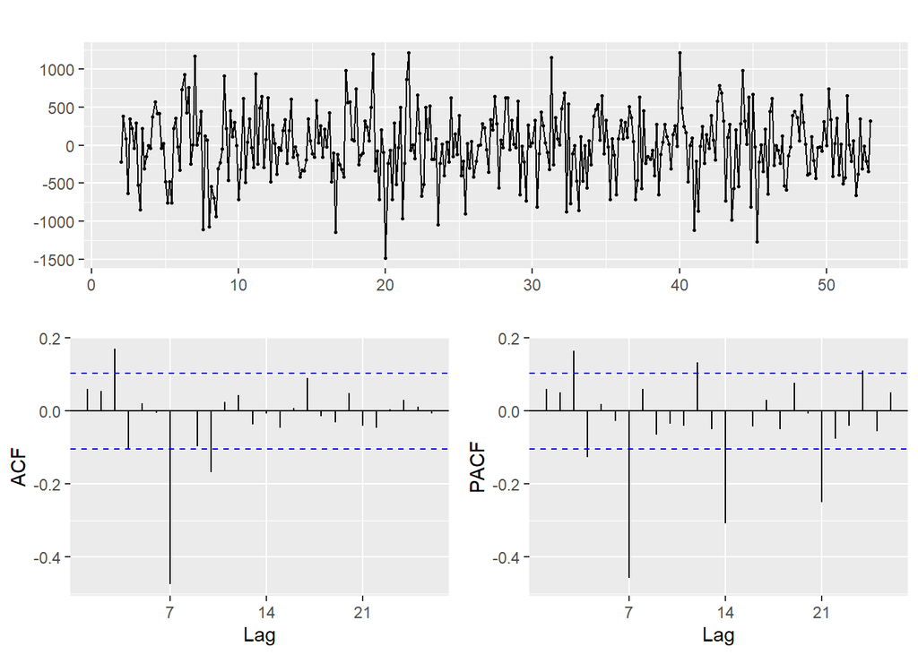

```r
ggtsdisplay(atm4  %>% diff(7))
```

```r
atm_model4 <- Arima(atm4, order=c(1,0,0), seasonal = c(0,1,0), lambda = atm4_lambda)
summary(atm_model4)
```

```
## Series: atm4
## ARIMA(1,0,0)(0,1,0)[7]
## Box Cox transformation: lambda= 0.4524377
##
## Coefficients:
##          ar1
##       0.0440
## s.e.  0.0528
##
## sigma^2 estimated as 297.2:  log likelihood=-1526.79
## AIC=3057.58   AICc=3057.61   BIC=3065.34
##
## Training set error measures:
##                     ME     RMSE      MAE       MPE     MAPE      MASE
## Training set -3.622377 447.8441 339.2516 -371.1099 425.4804 0.9793969
##                    ACF1
## Training set 0.01466724
```

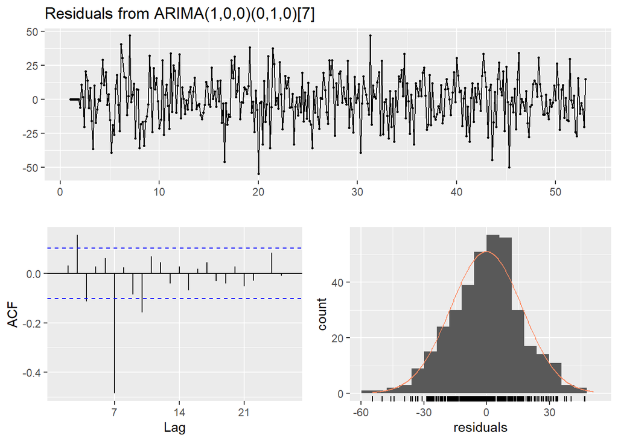

```
##
##  Ljung-Box test
##
## data:  Residuals from ARIMA(1,0,0)(0,1,0)[7]
## Q* = 120.15, df = 13, p-value < 2.2e-16
##
## Model df: 1.   Total lags used: 14
```

```r
checkresiduals(atm_model4)
```

```r
atm4_check <- auto.arima(atm4, approximation = FALSE, lambda = atm4_lambda)
summary(atm4_check)
```

```
## Series: atm4
## ARIMA(1,0,0)(2,0,0)[7] with non-zero mean
## Box Cox transformation: lambda= 0.4524377
##
## Coefficients:
##          ar1    sar1    sar2     mean
##       0.0770  0.2091  0.1995  28.9903
## s.e.  0.0526  0.0516  0.0525   1.2615
##
## sigma^2 estimated as 181.9:  log likelihood=-1466.06
## AIC=2942.11   AICc=2942.28   BIC=2961.61
##
## Training set error measures:
##                    ME     RMSE      MAE       MPE     MAPE      MASE
## Training set 84.40696 351.7723 274.2572 -354.4169 398.8866 0.7917625
##                    ACF1
## Training set 0.01970019
```

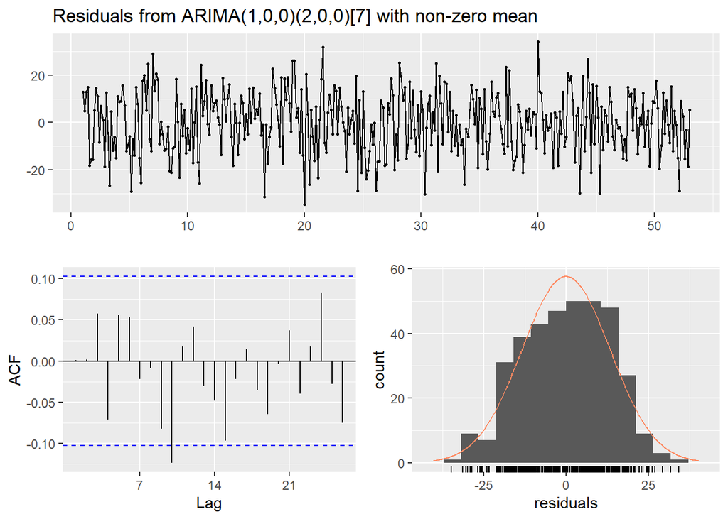

```
##
##  Ljung-Box test
##
## data:  Residuals from ARIMA(1,0,0)(2,0,0)[7] with non-zero mean
## Q* = 15.867, df = 10, p-value = 0.1035
##
## Model df: 4.   Total lags used: 14
```

```r
checkresiduals(atm4_check)
```

- I will go with the Auto model for this one. The AIC and AICc are lower.
  - Additionally the P-value from mine is significant
  - The Mean Error is negative, the RMSE is higher

```r
# imputing the Auto Arima into the list
atm_model5 <- Arima(atm4, order=c(1,0,0), seasonal = c(2,0,0), lambda = atm4_lambda)
```